## Connect With Us

- Website (https://www.rsquaredacademy.com/)
- Free Online R Courses (https://rsquared-academy.thinkific.com/)
- R Packages (https://pkgs.rsquaredacademy.com)
- Shiny Apps (https://apps.rsquaredacademy.com)
- Blog (https://blog.rsquaredacademy.com)
- GitHub (https://github.com/rsquaredacademy)
- YouTube (https://www.youtube.com/user/rsquaredin/)
- Twitter (https://twitter.com/rsquaredacademy)
- Facebook (https://www.facebook.com/rsquaredacademy/)
- Linkedin (https://in.linkedin.com/company/rsquared-academy)

## Resources

- [Slides](https://slides.rsquaredacademy.com/sql/sqlite.html#/section)
- [Blog Post](https://blog.rsquaredacademy.com/working-with-databases-using-r/)
- [Code & Data](https://github.com/rsquaredacademy-education/online-courses/)
- [RStudio Cloud](https://rstudio.cloud/project/430439)
- [Online Course](https://rsquared-academy.thinkific.com/courses/working-with-databases-using-r)
- connect to & explore database
- read & write data
- use RStudio SQL script & knitr SQL engine
- query data using dplyr
- visualize data with dbplot
- modeling data with modeldb & tidypredict
- explore RStudio connections pane
- handling credentials

## Libraries

```r
library(DBI)
library(dbplyr)
library(dplyr)
library(dbplot)
library(ggplot2)
library(modeldb)
library(tidypredict)
library(config)
```

## Connect

```r
con <- DBI::dbConnect(RSQLite::SQLite(), dbname = "mydatabase.db")
```

## Connection Summary

```r
summary(con)
```

```
##           Length            Class             Mode
##                1 SQLiteConnection               S4
```

## List Tables

```r
DBI::dbListTables(con)
```

```
## [1] "COMPANY"    "DEPARTMENT" "ecom"       "trade"
```

## List Fields

```r
DBI::dbListFields(con, "ecom")
```

```
##  [1] "id"          "referrer"    "device"      "bouncers"    "n_visit"
##  [6] "n_pages"     "duration"    "country"     "purchase"    "order_items"
## [11] "order_value"
```

## Querying Data

- read entire table
- read few rows
- read data in batches

## Entire Table

```r
DBI::dbReadTable(con, 'ecom')
```

```
##        id referrer device bouncers n_visit n_pages duration
## 1       1   google laptop     true      10       1      693
## 2       2    yahoo tablet     true       9       1      459
## 3       3   direct laptop     true       0       1      996
## 4       4     bing tablet    false       3      18      468
## 5       5    yahoo mobile     true       9       1      955
## 6       6    yahoo laptop    false       5       5      135
## 7       7    yahoo mobile     true      10       1       75
## 8       8   direct mobile     true      10       1      908
## 9       9     bing mobile    false       3      19      209
## 10     10   google mobile     true       6       1      208
## 11     11   direct laptop     true       9       1      738
## 12     12   direct tablet    false       6      12      132
## 13     13   direct mobile    false       9      14      406
## 14     14    yahoo tablet    false       5       8       80
```

[output cut: 1987 more lines]

## Few Rows

```r
DBI::dbGetQuery(con, "select * from ecom limit 10")
```

```
##    id referrer device bouncers n_visit n_pages duration        country
## 1   1   google laptop     true      10       1      693 Czech Republic
## 2   2    yahoo tablet     true       9       1      459          Yemen
## 3   3   direct laptop     true       0       1      996         Brazil
## 4   4     bing tablet    false       3      18      468          China
## 5   5    yahoo mobile     true       9       1      955         Poland
## 6   6    yahoo laptop    false       5       5      135   South Africa
## 7   7    yahoo mobile     true      10       1       75     Bangladesh
## 8   8   direct mobile     true      10       1      908      Indonesia
## 9   9     bing mobile    false       3      19      209    Netherlands
## 10 10   google mobile     true       6       1      208 Czech Republic
##    purchase order_items order_value
## 1     false           0           0
## 2     false           0           0
## 3     false           0           0
## 4      true           6         434
## 5     false           0           0
## 6     false           0           0
## 7     false           0           0
## 8     false           0           0
## 9     false           0           0
## 10    false           0           0
```

## Read Data in Batches

```r
query  <- DBI::dbSendQuery(con, 'select * from ecom')
result <- DBI::dbFetch(query, n = 30)
result
```

```
##    id referrer device bouncers n_visit n_pages duration        country
## 1   1   google laptop     true      10       1      693 Czech Republic
## 2   2    yahoo tablet     true       9       1      459          Yemen
## 3   3   direct laptop     true       0       1      996         Brazil
## 4   4     bing tablet    false       3      18      468          China
## 5   5    yahoo mobile     true       9       1      955         Poland
## 6   6    yahoo laptop    false       5       5      135   South Africa
## 7   7    yahoo mobile     true      10       1       75     Bangladesh
## 8   8   direct mobile     true      10       1      908      Indonesia
## 9   9     bing mobile    false       3      19      209    Netherlands
## 10 10   google mobile     true       6       1      208 Czech Republic
## 11 11   direct laptop     true       9       1      738        Jamaica
## 12 12   direct tablet    false       6      12      132        Estonia
## 13 13   direct mobile    false       9      14      406        Ireland
## 14 14    yahoo tablet    false       5       8       80    Philippines
```

[output cut: 47 more lines]

## Your Turn

- list fields in the `trade` table
- read all rows & columns from the `trade` table
- read first 30 rows from the `trade` table

## Query Status

```r
DBI::dbHasCompleted(query)
```

```
## [1] FALSE
```

## Query Info

```r
DBI::dbGetInfo(query)
```

```
## $statement
## [1] "select * from ecom"
##
## $row.count
## [1] 30
##
## $rows.affected
## [1] 0
##
## $has.completed
## [1] FALSE
```

## Latest Query

```r
DBI::dbGetStatement(query)
```

```
## [1] "select * from ecom"
```

## Rows Fetched

```r
DBI::dbGetRowCount(query)
```

```
## [1] 30
```

## Rows Affected

```r
DBI::dbGetRowsAffected(query)
```

```
## [1] 0
```

## Column Info

```r
DBI::dbColumnInfo(query)
```

```
##           name      type
## 1           id   integer
## 2     referrer character
## 3       device character
## 4     bouncers character
## 5      n_visit   integer
## 6      n_pages    double
## 7     duration    double
## 8      country character
## 9     purchase character
## 10 order_items    double
## 11 order_value    double
```

## Clear Results

```r
DBI::dbClearResult(query)
```

## Check Table Name

```r
DBI::dbExistsTable(con, "trial_db")
```

```
## [1] FALSE
```

## Create Table

```r
# sample data
x          <- 1:10
y          <- letters[1:10]
trial_data <- tibble::tibble(x, y)

# write table to database
DBI::dbWriteTable(con, "trial_db", trial_data)
```

## List Tables

```r
DBI::dbListTables(con)
```

```
## [1] "COMPANY"    "DEPARTMENT" "ecom"       "trade"      "trial_db"
```

## Query Data

```r
DBI::dbGetQuery(con, "select * from trial_db limit 5")
```

```
##   x y
## 1 1 a
## 2 2 b
## 3 3 c
## 4 4 d
## 5 5 e
```

## Overwrite Table

```r
# sample data
x           <- sample(100, 10)
y           <- letters[11:20]
trial2_data <- tibble::tibble(x, y)

# overwrite table trial
DBI::dbWriteTable(con, "trial_db", trial2_data, overwrite = TRUE)
```

## View Data

```r
DBI::dbGetQuery(con, "select * from trial_db")
```

```
##     x y
## 1  29 k
## 2  89 l
## 3  66 m
## 4  76 n
## 5   3 o
## 6  13 p
## 7  84 q
## 8  23 r
## 9  75 s
## 10 58 t
```

## Append Data

```r
# sample data
x           <- sample(100, 10)
y           <- letters[5:14]
trial3_data <- tibble::tibble(x, y)

# append data
DBI::dbWriteTable(con, "trial_db", trial3_data, append = TRUE)
```

## View Data

```r
DBI::dbGetQuery(con, "select * from trial_db")
```

```
##     x y
## 1  29 k
## 2  89 l
## 3  66 m
## 4  76 n
## 5   3 o
## 6  13 p
## 7  84 q
## 8  23 r
## 9  75 s
## 10 58 t
## 11 21 e
## 12 66 f
## 13 96 g
## 14 54 h
## 15 59 i
## 16 92 j
## 17 37 k
## 18 83 l
## 19 94 m
## 20 89 n
```

## Insert Rows

```r
DBI::dbExecute(con,
  "INSERT into trial_db (x, y) VALUES (32, 'c'), (45, 'k'), (61, 'h')"
)
```

```
## [1] 3
```

## View Data

```r
DBI::dbGetQuery(con, "select * from trial_db")
```

```
##     x y
## 1  29 k
## 2  89 l
## 3  66 m
## 4  76 n
## 5   3 o
## 6  13 p
## 7  84 q
## 8  23 r
## 9  75 s
## 10 58 t
## 11 21 e
## 12 66 f
## 13 96 g
## 14 54 h
## 15 59 i
## 16 92 j
## 17 37 k
## 18 83 l
## 19 94 m
## 20 89 n
## 21 32 c
## 22 45 k
## 23 61 h
```

## Insert Rows

```r
DBI::dbSendStatement(con,
  "INSERT into trial_db (x, y) VALUES (25, 'm'), (54, 'l'), (16, 'y')"
)
```

```
## <SQLiteResult>
##   SQL  INSERT into trial_db (x, y) VALUES (25, 'm'), (54, 'l'), (16, 'y')
##   ROWS Fetched: 0 [complete]
##        Changed: 3
```

## View Data

```r
DBI::dbGetQuery(con, "select * from trial_db")
```

```
##     x y
## 1  29 k
## 2  89 l
## 3  66 m
## 4  76 n
## 5   3 o
## 6  13 p
## 7  84 q
## 8  23 r
## 9  75 s
## 10 58 t
## 11 21 e
## 12 66 f
## 13 96 g
## 14 54 h
## 15 59 i
## 16 92 j
## 17 37 k
## 18 83 l
## 19 94 m
## 20 89 n
## 21 32 c
## 22 45 k
## 23 61 h
## 24 25 m
## 25 54 l
## 26 16 y
```

## Generate SQL Query

```r
DBI::sqlCreateTable(con, "new", c(x = "integer", y = "text"))
```

```
## <SQL> CREATE TABLE `new` (
##   `x` integer,
##   `y` text
## )
```

## Generate SQL Query

```r
trial_new <- data.frame(x = 30, y = 'k')
DBI::sqlAppendTable(con, "tria_db", trial_new)
```

```
## <SQL> INSERT INTO `tria_db`
##   (`x`, `y`)
## VALUES
##   (30, 'k')
```

## Remove Table

```r
DBI::dbRemoveTable(con, "trial_db")
```

## Your Turn

- check if `mytable` exists in the database
- create new table `mytable` using the first 3 rows of `mtcars` data set
- list all tables to check if the new table has been created
- overwrite `mytable` with the first 10 rows of `mtcars` data set
- append the 20th row of `mtcars` data set to `mytable`
- create a new table using the last 5 rows of `mtcars` and append it to `mytable`
- remove `mytable`

## Data Type

```r
DBI::dbDataType(RSQLite::SQLite(), "a")
```

```
## [1] "TEXT"
```

```r
DBI::dbDataType(RSQLite::SQLite(), 1:5)
```

```
## [1] "INTEGER"
```

```r
DBI::dbDataType(RSQLite::SQLite(), 1.5)
```

```
## [1] "REAL"
```

## Running SQL Scripts

[figure not shown]

## knitr SQL Engine

[figure not shown]

## Your Turn

- check the data type of `"NULL"`
- use SQL script to select `duration`, `n_visit` from `trade` table where `device` has the value `tablet`
- create a html report for the above sql query using the knitr SQL engine

## Reference Data

```r
ecom2 <- dplyr::tbl(con, "ecom")
ecom2
```

```
## # Source:   table<ecom> [?? x 11]
## # Database: sqlite 3.22.0 [J:\R\courses\tutorial_slides\sql\mydatabase.db]
##       id referrer device bouncers n_visit n_pages duration country purchase
##    <int> <chr>    <chr>  <chr>      <int>   <dbl>    <dbl> <chr>   <chr>
##  1     1 google   laptop true          10       1      693 Czech ~ false
##  2     2 yahoo    tablet true           9       1      459 Yemen   false
##  3     3 direct   laptop true           0       1      996 Brazil  false
##  4     4 bing     tablet false          3      18      468 China   true
##  5     5 yahoo    mobile true           9       1      955 Poland  false
##  6     6 yahoo    laptop false          5       5      135 South ~ false
##  7     7 yahoo    mobile true          10       1       75 Bangla~ false
##  8     8 direct   mobile true          10       1      908 Indone~ false
##  9     9 bing     mobile false          3      19      209 Nether~ false
## 10    10 google   mobile true           6       1      208 Czech ~ false
## # ... with more rows, and 2 more variables: order_items <dbl>,
## #   order_value <dbl>
```

## Query Data

```r
tos_query <-
  ecom2 %>%
  dplyr::select(referrer, device, duration) %>%
  dplyr::filter(device == "laptop") %>%
  dplyr::group_by(referrer) %>%
  dplyr::summarise(avg_tos = mean(duration)) %>%
  dplyr::arrange(avg_tos)

tos_query
```

```
## # Source:     lazy query [?? x 2]
## # Database:   sqlite 3.22.0
## #   [J:\R\courses\tutorial_slides\sql\mydatabase.db]
## # Ordered by: avg_tos
##   referrer avg_tos
##   <chr>      <dbl>
## 1 direct      326.
## 2 yahoo       331.
## 3 social      362.
## 4 bing        434.
## 5 google      439.
```

## Collect Data

```r
result <-
  ecom2 %>%
  dplyr::select(referrer, device)

result
```

```
## # Source:   lazy query [?? x 2]
## # Database: sqlite 3.22.0 [J:\R\courses\tutorial_slides\sql\mydatabase.db]
##    referrer device
##    <chr>    <chr>
##  1 google   laptop
##  2 yahoo    tablet
##  3 direct   laptop
##  4 bing     tablet
##  5 yahoo    mobile
##  6 yahoo    laptop
##  7 yahoo    mobile
##  8 direct   mobile
##  9 bing     mobile
## 10 google   mobile
## # ... with more rows
```

## Collect Data

```r
nrow(result)
```

```
## [1] NA
```

## Collect Data

```r
result %>%
  dplyr::collect()
```

```
## # A tibble: 1,000 x 2
##    referrer device
##    <chr>    <chr>
##  1 google   laptop
##  2 yahoo    tablet
##  3 direct   laptop
##  4 bing     tablet
##  5 yahoo    mobile
##  6 yahoo    laptop
##  7 yahoo    mobile
##  8 direct   mobile
##  9 bing     mobile
## 10 google   mobile
## # ... with 990 more rows
```

## Collect Data

```r
result %>%
  dplyr::collect() %>%
  nrow()
```

```
## [1] 1000
```

## Display Query

```r
dplyr::show_query(tos_query)
```

```
## <SQL>
## SELECT `referrer`, AVG(`duration`) AS `avg_tos`
## FROM (SELECT `referrer`, `device`, `duration`
## FROM `ecom`)
## WHERE (`device` = 'laptop')
## GROUP BY `referrer`
## ORDER BY `avg_tos`
```

## SQL Generation

```r
ecom2 %>%
  dplyr::group_by(referrer) %>%
  dplyr::summarise(avg_tos = mean(duration))  %>%
  dbplyr::sql_render(dbplyr::simulate_mysql())
```

```
## <SQL> SELECT `referrer`, AVG(`duration`) AS `avg_tos`
## FROM `ecom`
## GROUP BY `referrer`
```

## Your Turn

- use `tbl()` to reference `trade` table as `trade2`
- use dplyr verbs to compute average duration for `device` from the `trade` table
- store the above query in a variable `tos_device`
- use `show_query()` to display the underlying SQL query of `tos_device`
- use `collect()` to retrieve data from `tos_device`
- use `explain()` to display the underlying computation logic of `tos_device`

## dbplot

- box plot
- bar plot
- histogram
- line chart
- raster plot

## Bar Plot

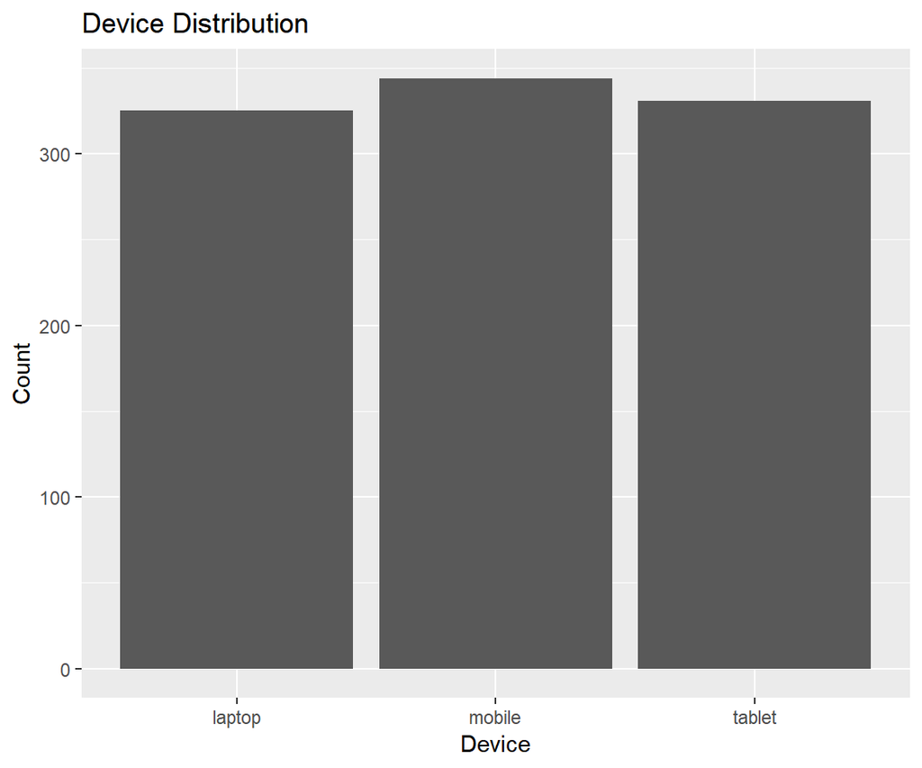

```r
ecom2 %>%
  dbplot::dbplot_bar(device) + ggplot2::xlab("Device") + ggplot2::ylab("Count") + ggplot2::ggtitle("Device Distribution")
```

## Line Chart

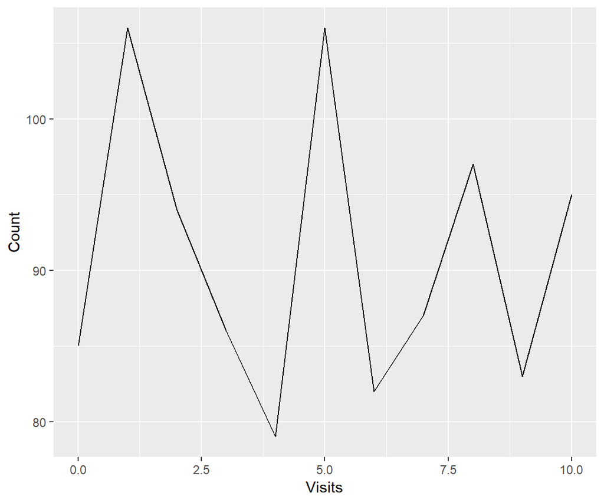

```r
ecom2 %>%
  dbplot::dbplot_line(n_visit) + ggplot2::xlab("Visits") + ggplot2::ylab("Count")
```

## Your Turn

- create bar plot of `referrer` column from the `trade` table
- create line chart of `n_visit` column from the `trade` table

## Modeling

- [modeldb](https://tidymodels.github.io/modeldb/index.html)
- [tidypredict](https://tidymodels.github.io/tidypredict/index.html)

## Simple Regression

```r
ecom2 %>%
  dplyr::select(duration, n_visit) %>%
  modeldb::linear_regression_db(duration)
```

```
## # A tibble: 1 x 2
##   `(Intercept)` n_visit
##           <dbl>   <dbl>
## 1          364.   -1.72
```

## Multiple Regression

```r
ecom2 %>%
  dplyr::select(duration, n_visit, n_pages) %>%
  modeldb::linear_regression_db(duration)
```

```
## # A tibble: 1 x 3
##   `(Intercept)` n_visit n_pages
##           <dbl>   <dbl>   <dbl>
## 1          415.   -2.02   -8.37
```

## Categorical Variables

```r
ecom2 %>%
  dplyr::select(duration, device) %>%
  modeldb::add_dummy_variables(device, values = c("laptop", "mobile", "tablet")) %>%
  modeldb::linear_regression_db(duration)
```

```
## # A tibble: 1 x 3
##   `(Intercept)` device_mobile device_tablet
##           <dbl>         <dbl>         <dbl>
## 1          376.         -39.2         -22.1
```

## Full Example

```r
ecom2 %>%
  dplyr::select(duration, n_visit, n_pages, device) %>%
  modeldb::add_dummy_variables(device, values = c("laptop", "mobile", "tablet")) %>%
  modeldb::linear_regression_db(duration, sample_size = 1000)
```

```
## # A tibble: 1 x 5
##   `(Intercept)` n_visit n_pages device_mobile device_tablet
##           <dbl>   <dbl>   <dbl>         <dbl>         <dbl>
## 1          427.   -1.52   -8.27         -31.1         -14.4
```

## Your Turn

- regress `duration` on `n_pages`
- regress `duration` on `referrer`
- and finally regress `duration` on `n_pages`, `n_visit` and `referrer`

## Predict Inside Database

```r
model <- lm(duration ~ device + referrer + n_visit + n_pages, data = ecom2)
model
```

```
##
## Call:
## lm(formula = duration ~ device + referrer + n_visit + n_pages,
##     data = ecom2)
##
## Coefficients:
##    (Intercept)    devicemobile    devicetablet  referrerdirect
##        441.450         -30.952         -14.497          -8.980
## referrergoogle  referrersocial   referreryahoo         n_visit
##        -10.038         -19.841         -32.097          -1.433
##        n_pages
##         -8.298
```

## Fit

```r
tidypredict::tidypredict_fit(model)
```

```
## 441.450192491919 + (ifelse(device == "mobile", 1, 0) * -30.9522074131866) +
##     (ifelse(device == "tablet", 1, 0) * -14.4972018107797) +
##     (ifelse(referrer == "direct", 1, 0) * -8.98035001912995) +
##     (ifelse(referrer == "google", 1, 0) * -10.038005625893) +
##     (ifelse(referrer == "social", 1, 0) * -19.8411767075006) +
##     (ifelse(referrer == "yahoo", 1, 0) * -32.0969778768984) +
##     (n_visit * -1.4325653130794) + (n_pages * -8.29825840984566)
```

## Fit

```r
ecom2 %>%
  tidypredict::tidypredict_to_column(model) %>%
  dplyr::select(duration, fit)
```

```
## # Source:   lazy query [?? x 2]
## # Database: sqlite 3.22.0 [J:\R\courses\tutorial_slides\sql\mydatabase.db]
##    duration   fit
##       <dbl> <dbl>
##  1      693  409.
##  2      459  374.
##  3      996  424.
##  4      468  273.
##  5      955  357.
##  6      135  361.
##  7       75  356.
##  8      908  379.
##  9      209  249.
## 10      208  384.
## # ... with more rows
```

## SQL

```r
tidypredict::tidypredict_sql(model, con)
```

[output not shown]

## Close Connection

```r
DBI::dbDisconnect(con)
```

## Handling Credentials

- .Renviron
- options
- config
- keyring

## Summary

- [DBI](http://r-dbi.github.io/DBI/) to connect and interact with databases
- [dplyr](https://dplyr.tidyverse.org/index.html) and [dbplyr](https://dbplyr.tidyverse.org/index.html) for data transformation
- [dbplot](https://edgararuiz.github.io/dbplot/index.html) for data visualization
- [modeldb](https://tidymodels.github.io/modeldb/) and [tidypredict](https://tidymodels.github.io/tidypredict/) for data modeling
- config, keyring, .Renviron and `options()` to handle credentials
- always close the database connection

## References

- [RStudio Webinar](https://resources.rstudio.com/webinars/modeling-in-databases-with-r)
- [Databases Using R](https://db.rstudio.com/)
- [DBI](http://r-dbi.github.io/DBI/)
- [dbplyr](https://dbplyr.tidyverse.org/index.html)
- [dbplot](https://edgararuiz.github.io/dbplot/index.html)
- [modeldb](https://tidymodels.github.io/modeldb/)
- [tidypredict](https://tidymodels.github.io/tidypredict/)
- config
- keyring